# ggplot - Statistical transformations

# 5 overplotting

בתרשים הבא, יש נקודות חופפות

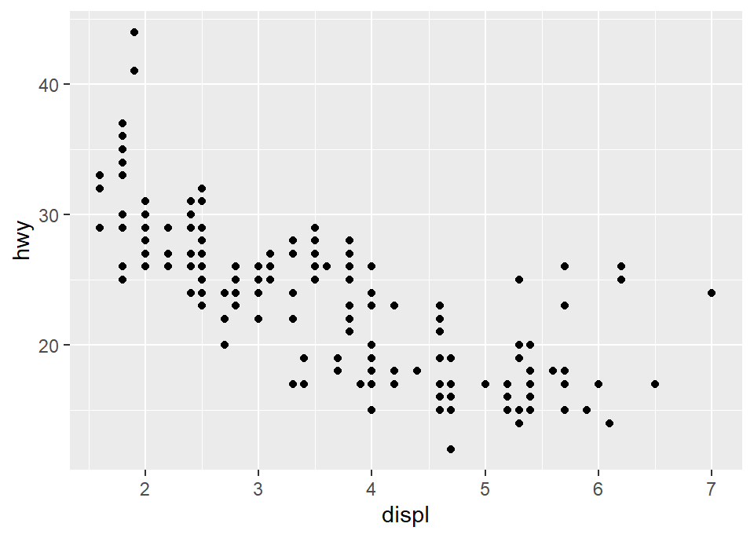

```r
ggplot(mpg, aes(displ, hwy)) + geom_point()
```

אפשר להוסיף jitter לגרף, זה מוסיף רעש רנדומאלי למיקום של כל נקודה.

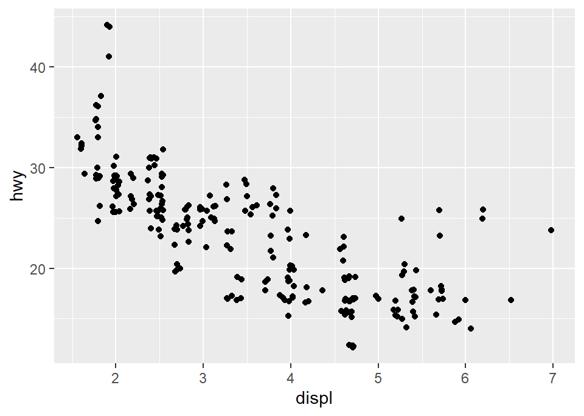

```r
ggplot(data = mpg) +
  geom_point(mapping = aes(x = displ, y = hwy), position = "jitter")
```

כאשר יש מעט נתונים זה הופך את הגרף לפחות מדויק, אך כשיש הרבה נתונים זה הופך את הגרף ליותר גלוי.

# 6 collective geoms

Collective geom מציג מספר תצפיות עם אובייקט גיאומטרי אחד.  
ברירת המחדל עבור ה-group aesthetic היא לאינטראקציה בין כל המשתנים הבדידים בגרף.  
יש מקרים שזה לא מספיק.

הנה נתוני פאנל על גובה של נערים:

```r
data(Oxboys, package = "nlme")
head(Oxboys)
```

```
##   Subject     age height Occasion
## 1       1 -1.0000  140.5        1
## 2       1 -0.7479  143.4        2
## 3       1 -0.4630  144.8        3
## 4       1 -0.1643  147.1        4
## 5       1 -0.0027  147.7        5
## 6       1  0.2466  150.2        6
```

אפשר לראות שהפרטים הופכים גבוהים יותר כשהמדידות מתקדמות

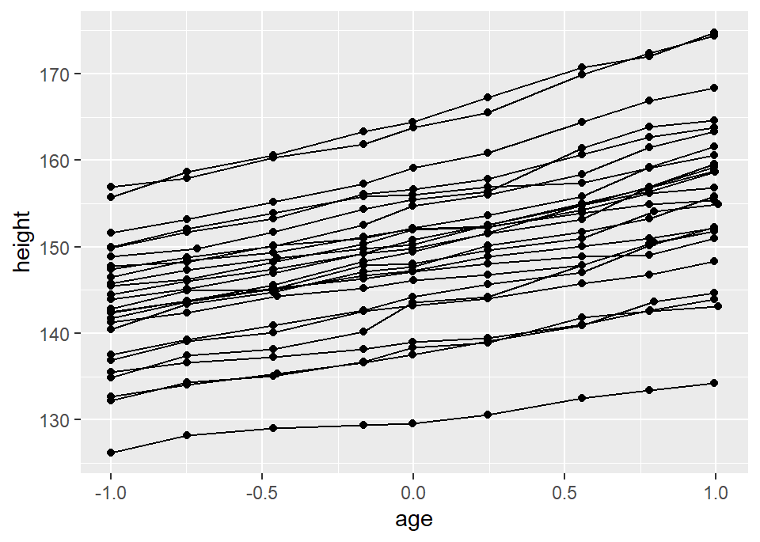

```r
ggplot(Oxboys, aes(age, height, group = Subject)) +
  geom_point() +
  geom_line()
```

מבלי לעשות group נקבל:

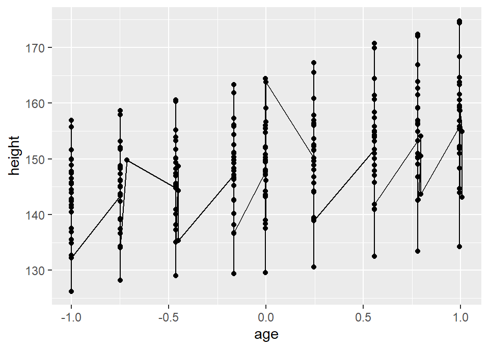

```r
ggplot(Oxboys, aes(age, height)) +
  geom_point() +
  geom_line()
```

אם רוצים לעשות אינטראקציה בין שני משתנים ניתן לעשות זאת בשימוש הפונקציה `interaction` באופן הבא:

`aes(group = interaction(school_id, student_id))`

בדוגמא הזו נרצה לקבץ כל פרט בנפרד. אפשר לשים את ארגומט ה-group ב-geom המסוים:

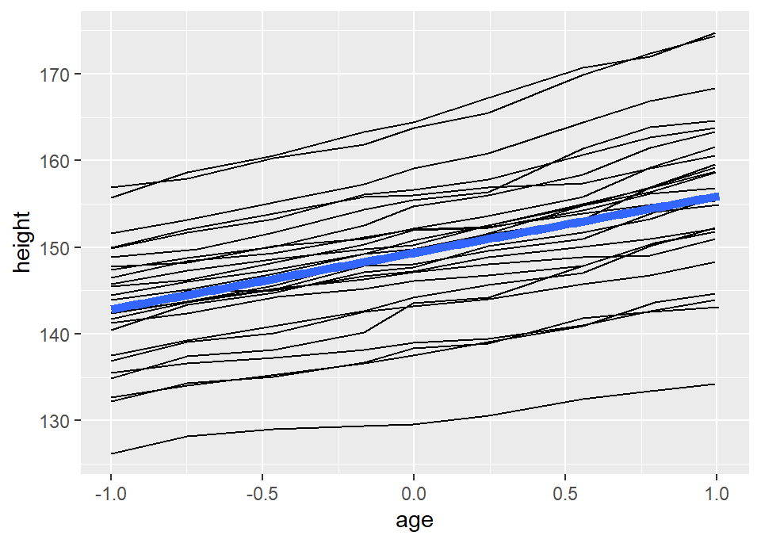

```r
ggplot(Oxboys, aes(age, height)) +
  geom_line(aes(group = Subject)) +
  geom_smooth(method = "lm", size = 2, se = FALSE)
## `geom_smooth()` using formula 'y ~ x'
```

מה אם ציר ה –x הוא דיסקרטי?

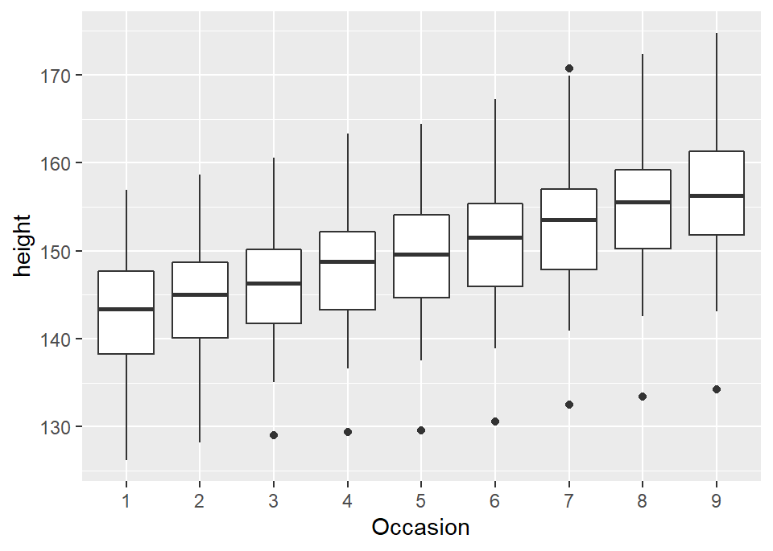

```r
ggplot(Oxboys, aes(Occasion, height)) +
  geom_boxplot()
```

`occasion` הוא משתנה דיסקרטי, `geom_line` לא יעבוד

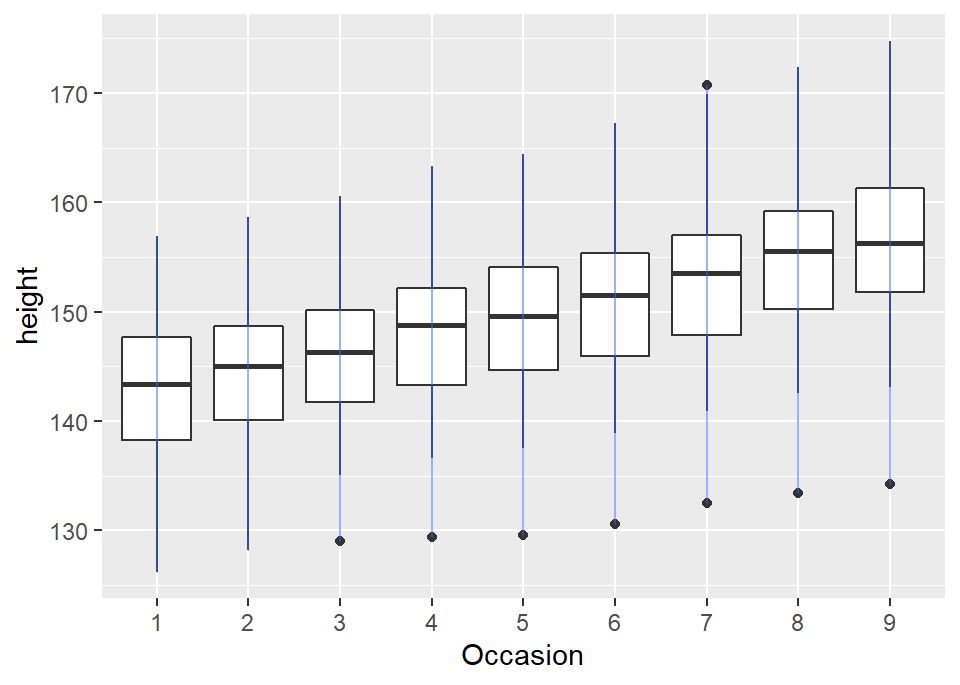

```r
ggplot(Oxboys, aes(Occasion, height)) +
  geom_boxplot() +
  geom_line(colour = "#3366FF", alpha = 0.5)
```

`geom_line` עושה גרף קווים המחבר נקודות משמאל לימין. ה-group aesthetic קובע אילו תצפיות מחוברות זו לזו.  
`geom_path` מחבר נקודות בסדר שהן מופיעות בנתונים.

עלינו לומר ל ggplot כיצד לחבר את התצפיות. למשל, נרצה קו אחד לכל פרט:

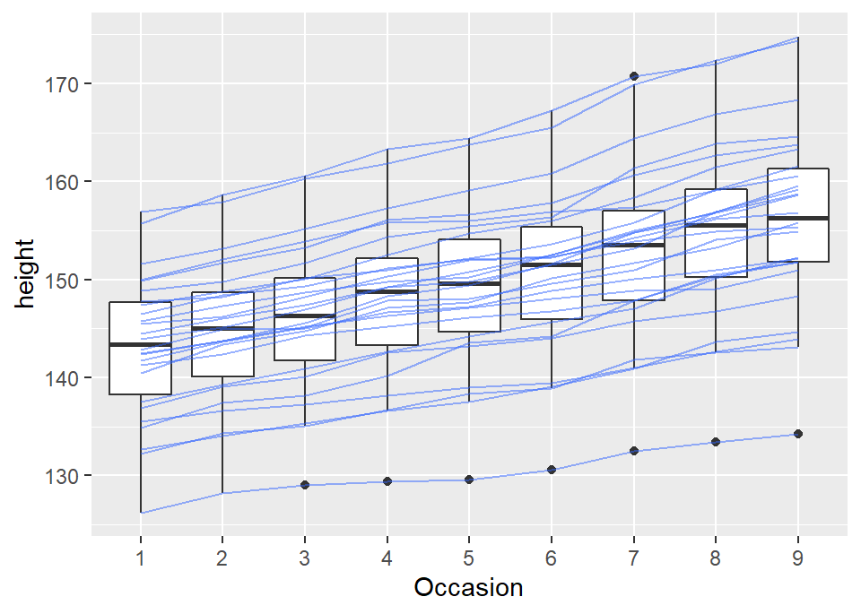

```r
ggplot(Oxboys, aes(Occasion, height)) +
  geom_boxplot() +
  geom_line(aes(group = Subject), colour = "#3366FF", alpha = 0.5)
```

# 7 exercises

1. חקור את התפלגות המחיר (price) של יהלומים. האם גילית משהו לא רגיל או מפתיע? רמז, בדוק `binwidth` שונים.
2. כמה יהלומים הם 0.99 קראט? כמה עם 1 קראט? מדוע לדעתך יש הבדל?
3. השווה בין `coord_cartezian` לבין `xlim` and `ylim` כאשר עושים zoom in על היסטוגרמה. מה קורה אם משאירים את ה `binwidth` ללא שינוי? מה קורה אם עושים זום כך שרואים רק חצי מה-bar?
4. מה קורה לערכים חסרים בהיסטוגרמה? מה קורה לערכים חסרים ב-bar plot? מדוע יש הבדל?
5. השווה בין `geom_vilolin` לבין היסטוגרמה מחולקת ל-`facets` לבין `geom_freqpoly` מחולק לצבעים. מה היתרונות והחסרונות של כל אחת מהאפשרויות. (לצורך התרגיל ניתן להציג התפלגויות של price לפי cut).
6. הצג את ההתפלגות של קראט בפילוח לפי מחיר היהלומים.
7. כאשר טבלת הנתונים קטנה, לעיתים נח להשתמש ב- `geom_jitter` בכדי לראות את הקשר בין משתנה רציף ומשתנה קטגורי. בחבילה ggbeeswarm יש מספר אפשרויות דומות ל- geom_jitter. בחן את האפשרויות שהחבילה מציעה.
8. תוך שימוש בטבלת הנתונים mpg צור גרף של `hwy` עבור כל ערך של `cyl` מבלי להפוך את המשתנה `cyl` ל-factor. באיזה aesthetic צריך להשתמש?
9. שנה את הגרף הבא כך שיתקבל boxplot לכל ערך שלם של displ.

```r
ggplot(mpg, aes(displ, cty)) +
  geom_boxplot()
```

10. כשהצגנו barplot עם פרופורציות של –cut מתוך כלל היהלומים, השתמשנו ב- `group = 1`. מדוע?
11. כמה bars יש בכל אחד מהגרפים הבאים?  
    (רמז: כדי לתחום את חלקי ה-bars השתמש ב- `color = "white"`).

```r
ggplot(mpg, aes(drv)) +
  geom_bar()

ggplot(mpg, aes(drv, fill = hwy, group = hwy)) +
  geom_bar()

mpg2 <- mpg %>% arrange(hwy) %>% mutate(id = seq_along(hwy))

ggplot(mpg2, aes(drv, fill = hwy, group = id)) +
  geom_bar()
```